# Cryptography Course AD Analysis

## Exploratory data analysis

### Univariate analysis

#### Descriptive statistics

```r
# Value counts - Clicked on Ad
table(df$`Clicked on Ad`)
```

```
##
##   0   1
## 500 500
```

We had an equal number of not-clicked and clicked users

```r
# Describe method Keys:
# vars - number of columns being described
# n - number of rows
# mean - mean of column
# sd - standard deviation of column
# min - minimum value in column
# max - maximum value in column
# range - difference between minimum and maximum value
# se - standard error of column


# Time spent on site described
describe(df$`Daily Time Spent on Site`, interp = TRUE, skew = FALSE, trim = 0.1, quant = NULL, IQR = FALSE)
```

```
##    vars    n mean    sd  min   max range  se
## X1    1 1000   65 15.85 32.6 91.43 58.83 0.5
```

It looked like most users spent around 65 minutes on the site. Which meant, that users were more skewed towards the higher side of the time than the lower side.

```r
# Area income described
describe(df$`Area Income`, interp = TRUE, skew = FALSE, trim = 0.1, quant = NULL, IQR = FALSE)
```

```
##    vars    n  mean       sd     min     max   range     se
## X1    1 1000 55000 13414.63 13996.5 79484.8 65488.3 424.21
```

```r
# Daily internet usage described
describe(df$`Daily Internet Usage`, interp = TRUE, skew = FALSE, trim = 0.1, quant = NULL, IQR = FALSE)
```

```
##    vars    n mean   sd    min    max  range   se
## X1    1 1000  180 43.9 104.78 269.96 165.18 1.39
```

```r
# Mode function
getMode <- function(v) {
   uniqv <- unique(v)
   uniqv[which.max(tabulate(match(v, uniqv)))]
}
```

```r
minAge = min(df$Age)
maxAge = max(df$Age)
meanAge = mean(df$Age)
modeAge = getMode(df$Age)

cat("Age min: ", minAge, "\n")
```

```
## Age min:  19
```

```r
cat("Age max: ", maxAge, "\n")
```

```
## Age max:  61
```

```r
cat("Age mean: ", meanAge, "\n")
```

```
## Age mean:  36.009
```

```r
cat("Age mode: ", modeAge)
```

```
## Age mode:  31
```

For age it looks like the min in 19, which would be expected. Since this is learning blog. While the mean is 36, which is also Ok. It doesn’t look abnormal. Then the max is 61 years.

#### Visualizations

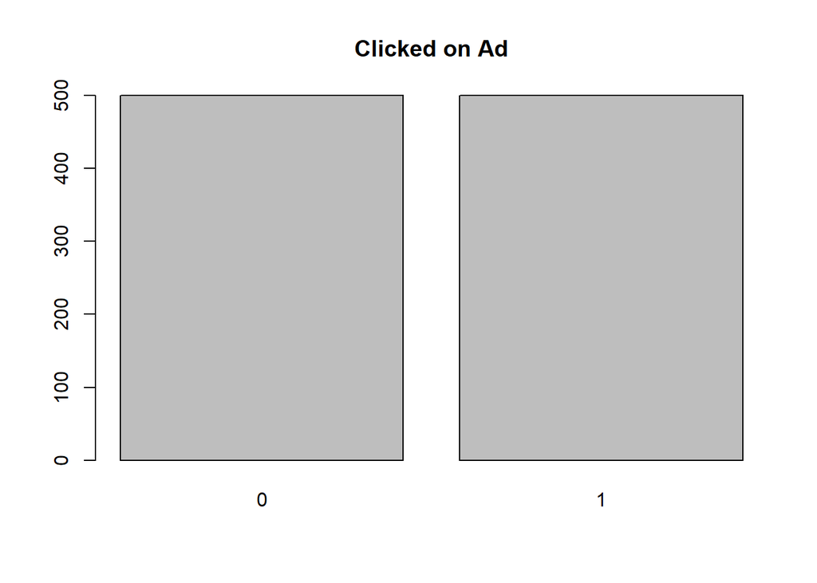

```r
barplot(table(df$`Clicked on Ad`), main = "Clicked on Ad")
```

There was an even number of users who clicked on the Ad and did not.

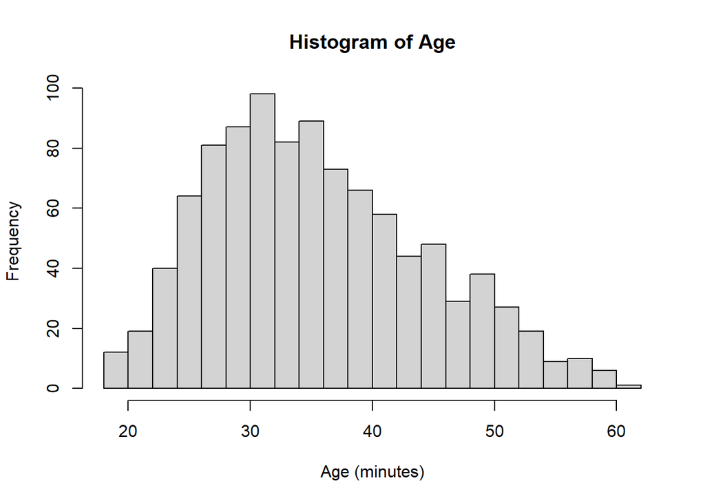

```r
hist(df$Age, breaks = 17, main = "Histogram of Age", xlab = "Age (minutes)")
```

It looks like most users are around 30 years. Then it declines from there.

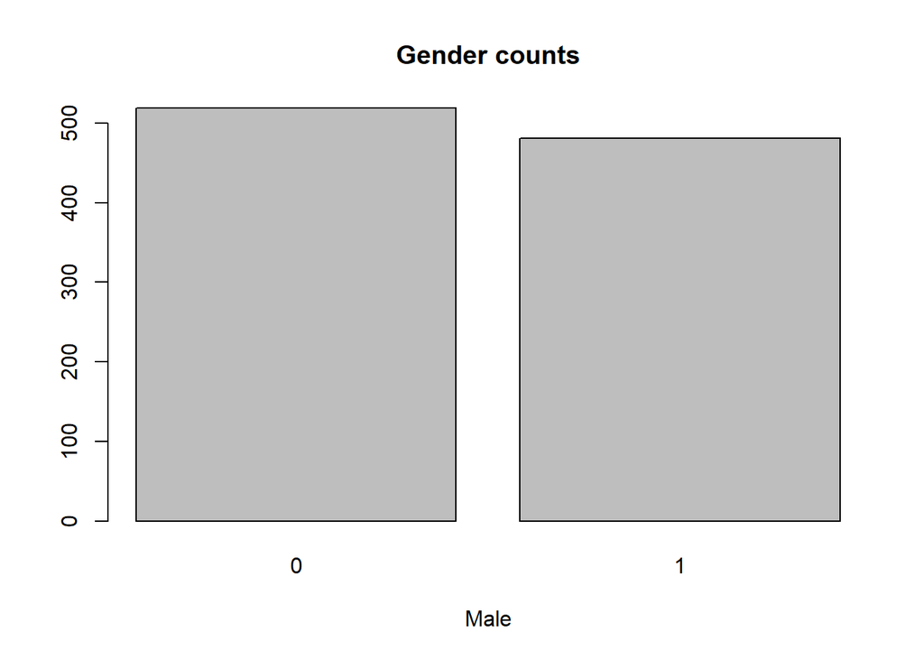

```r
barplot(table(df$Male), main = "Gender counts", xlab = "Male")
```

There were more females than males in the study.

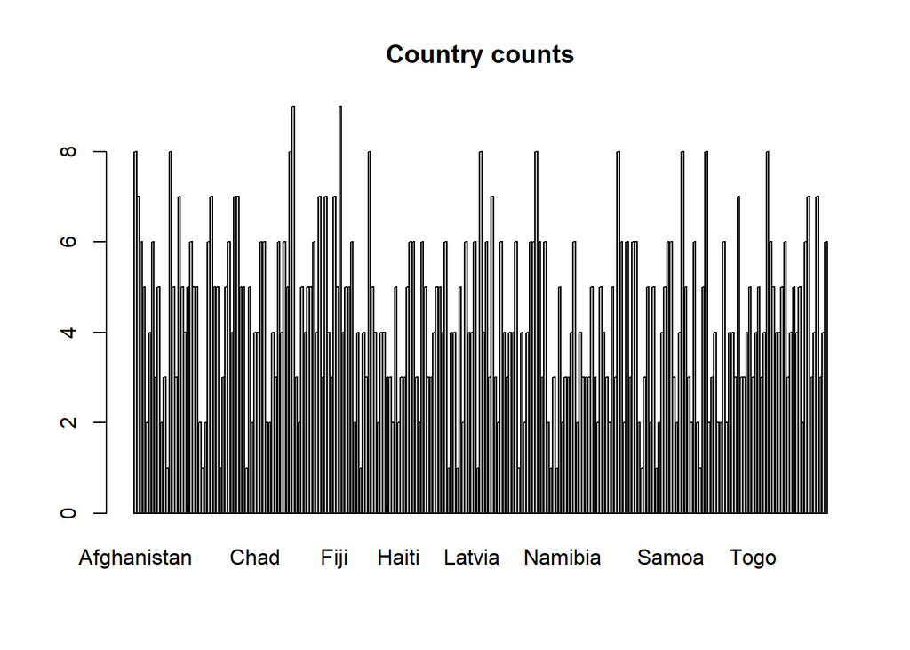

```r
barplot(table(df$Country), main = "Country counts")
```

There were several users from different countries. Which means our analysis will allow us to collect data from different countries. Which means it can be used in other areas. Where any website is being used to determine whether someone will click on an Ad or not.

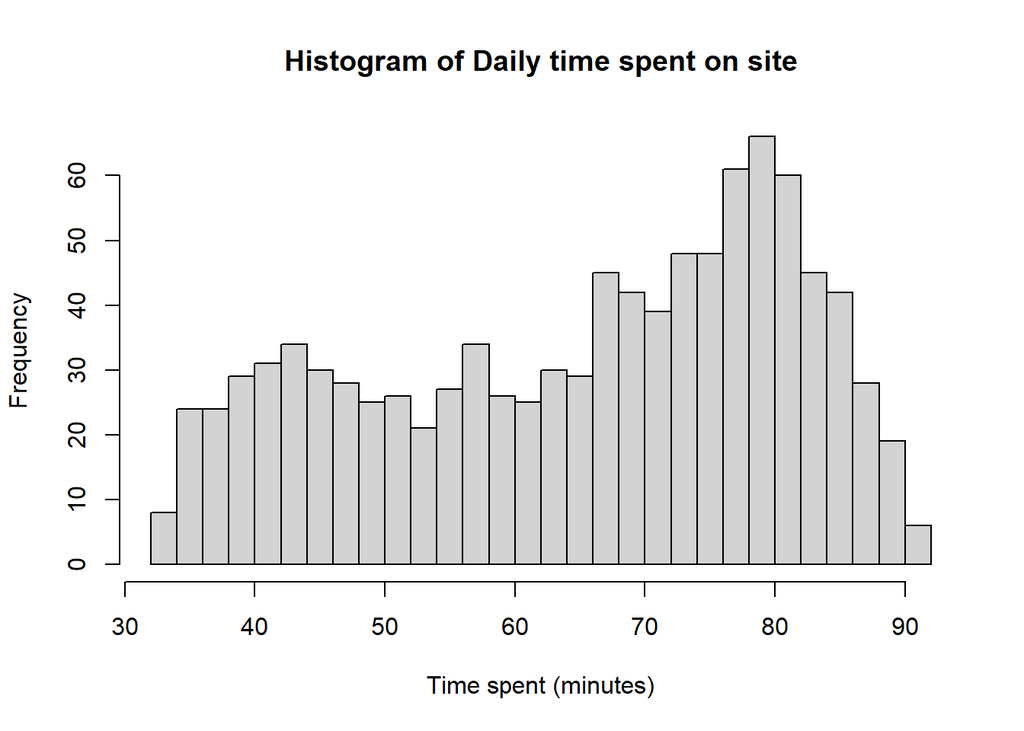

```r
# Distribution plots

hist(df$`Daily Time Spent on Site`, breaks = 30, main = "Histogram of Daily time spent on site", xlab = "Time spent (minutes)")
```

It’s generally evenly distributed. However there are more people who spent around 80 minutes. Than there are that spent 52 minutes. This means there was a wide collection of users from the survey.

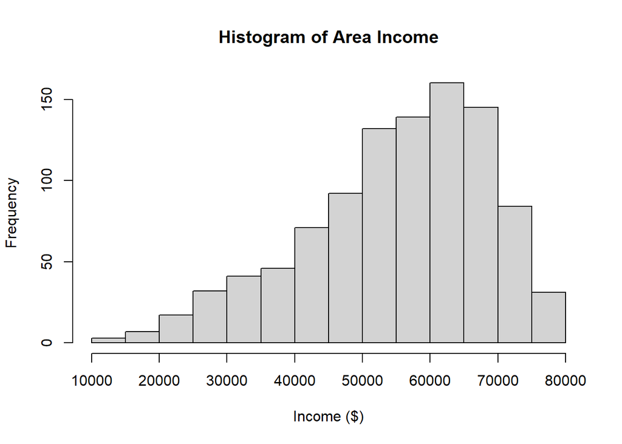

```r
hist(df$`Area Income`, breaks = 23, main = "Histogram of Area Income", xlab = "Income ($)")
```

Looks like it’s normally distributed. However it seems to be leaning towards 64,000. This means that those on the blog, generally had more money. So they were able to afford the things being offered on the blog. For example, the courses that he wants to advertise.

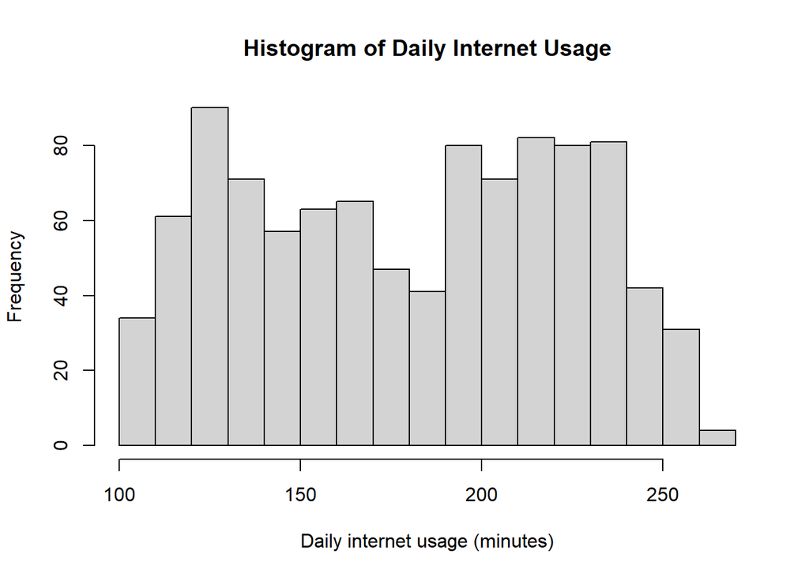

```r
hist(df$`Daily Internet Usage`, breaks = 20, main = "Histogram of Daily Internet Usage", xlab = "Daily internet usage (minutes)")
```

It seems that those using the internet. Peaked at 130 minutes. Then went down, and peaked again at 220 minutes. THis means there are generally two types of users. Those that used the internet for 130 miuntes a day, short users. Those that use it for 220 minutes, long users.

### Bivariate analysis

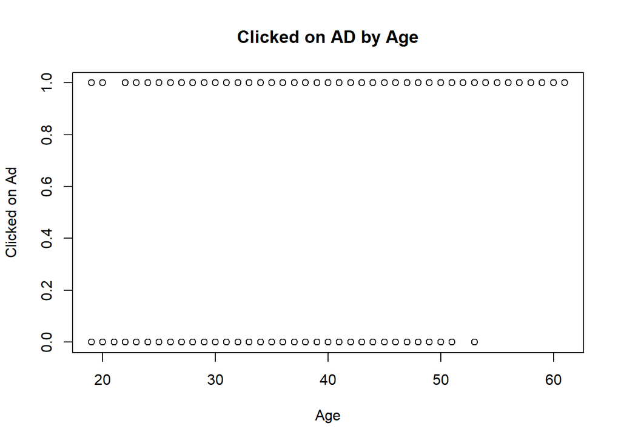

```r
plot(df$Age, df$`Clicked on Ad`, main = "Clicked on AD by Age", xlab = "Age", ylab = "Clicked on Ad")
```

Those that were older were more likely to click on the Ad.

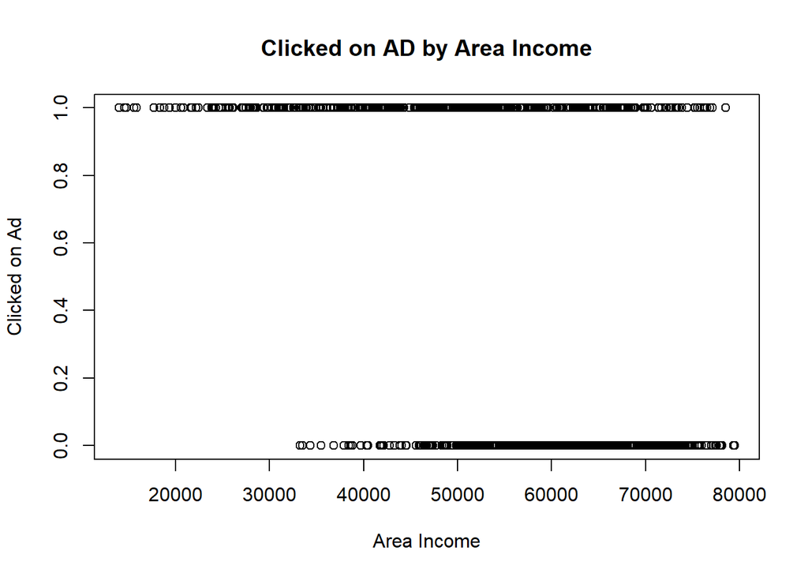

```r
plot(df$`Area Income`, df$`Clicked on Ad`, main = "Clicked on AD by Area Income", xlab = "Area Income", ylab = "Clicked on Ad")
```

Those with less income were more likely to click on the Ad. most probably because they spent more time on the internet

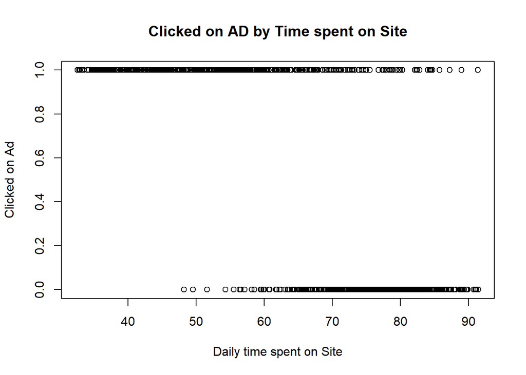

```r
plot(df$`Daily Time Spent on Site`, df$`Clicked on Ad`, main = "Clicked on AD by Time spent on Site", xlab = "Daily time spent on Site", ylab = "Clicked on Ad")
```

Those that spent less time. Were more likely to click on the Ad.

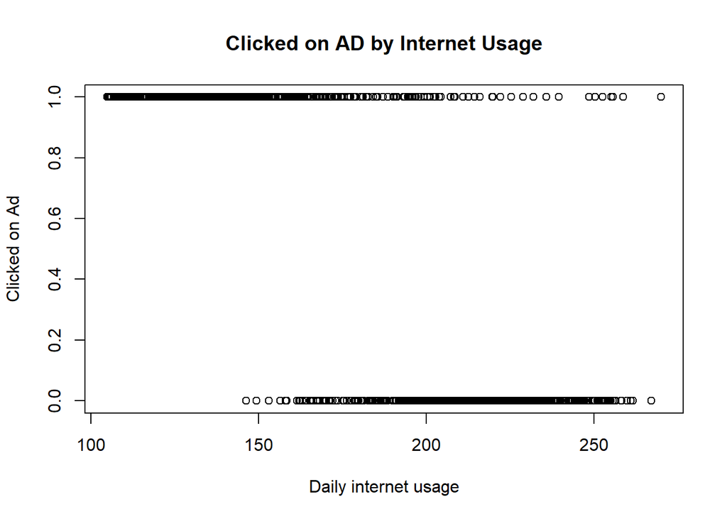

```r
plot(df$`Daily Internet Usage`, df$`Clicked on Ad`, main = "Clicked on AD by Internet Usage", xlab = "Daily internet usage", ylab = "Clicked on Ad")
```

Those that spent less time, were more likely to click on the Ad.

```r
correlation = correlate(select(df, `Daily Time Spent on Site`, Age, `Area Income`, `Daily Internet Usage`, Male, `Clicked on Ad`))
```

```
##
## Correlation method: 'pearson'
## Missing treated using: 'pairwise.complete.obs'
```

```r
correlation[c("term","Clicked on Ad")]
```

```
## # A tibble: 6 x 2
##   term                     `Clicked on Ad`
##   <chr>                              <dbl>
## 1 Daily Time Spent on Site         -0.748
## 2 Age                               0.493
## 3 Area Income                      -0.476
## 4 Daily Internet Usage             -0.787
## 5 Male                             -0.0380
## 6 Clicked on Ad                    NA
```

```r
# focus(correlation, `Clicked on Ad`)
```

## Conclusion

It seems that the only variable that had a positive correlation on the “clicked on Ad” field, was Age. This means that to determine whether someone will click on an Ad. The kenyan entrepreneur also needs to look at those that spent less amount of time on the site. As well as on the internet. Then those that live in poorer countries. This in combination with age, is a good predictor of who will click on the Ad.

So the main predictor variables are:  
1. Daily internet usage - negative  
2. Daily time spent on site - negative  
3. Age - positive  
4. Area income - negative

These are the variables that the Kenyan entrepreneur needs to look out for. Where negative means, low values are more likely to click on the ad. Whereas positive correlations, mean higher values produce a chance for someone to click on the ad.

## Recommendation

I recommend that the kenyan entrepreneur targets his ads. To those who live in low income areas. Then he can further target it to those who use the internet less. By increasing the number of times it appears blogs. So after finding the blogs that appeal most to users from low income areas, he can increase the frequency. Then he can offer promotions for those courses. Since older people prefer promotions than paying full price. These are the steps I would recommend to the kenyan entrepreneur, to increase the sales of his course on his site.